# Expresión Diferencial en RNA-seq: edgeR

Asier Ortega Legarreta

2021-06-09

# Tarea 41

```r
doAll = TRUE
```

Cargamos todas las librerías que utilizaremos.

- pacman: Package Management Tool
- asierortega: contains the data we going to work with, and useful functions.
- limma: Linear Models for Microarray Data.
- edgeR: Empirical Analysis of Digital Gene Expression Data in R.
- ReportingTools: Tools for making reports in various formats.
- SummarizedExperiment: SummarizedExperiment container.

```r
library(pacman)
library(asierortega)
pacman::p_load(SummarizedExperiment)
pacman::p_load(edgeR)
pacman::p_load(ggplot2)
pacman::p_load(ReportingTools)
```

### Carga de datos

Cargamos el **PRJNA548871.rda** generado en la tarea 2 (llamado PRJNA548871.Rmd) de RNA-seq.

```r
data(PRJNA548871, package = "asierortega")
```

Quitaremos aquellos genes que no estén anotados por ninguna de las tres identificadores que le añadimos “GENENAME”, “ENTREZID” y “SYMBOL”. He creado una función que quita todas aquellas filas que no tenga ninguna de las columnas anotadas dentro del paquete “asierortega”. La función se llama “cleanNA”. A continuación se muestra lo que realiza la función.

```r
PRJNA548871 = PRJNA548871[which(apply(rowData(PRJNA548871),1,function(y) sum(is.na(y))!=3)),]
PRJNA548871_funcion = cleanNA(PRJNA548871, Ncolumns = 3)
```

### Análisis de expresión diferencial con EdgeR

A continuación analizaremos la expresión diferencial de nuestros datos de RNA-seq. Recordemos que tenemos 16 muestras de microglia en total donde 8 de ellas en la que se han inducido por teinopatía por oxígeno (OIR), y otros 8 en las que no (nonOIR) (controles). Este experimento no contiene covariables.

Para realizar el análisis nos debemos fijar en la columna de “treatment” debido a que es en la que se específica aquellas muestras donde se ha aplicado el tratamiento (OIR) y en los que no (nonOIR).

Crearemos un objeto tipo de clase dgeList, este objeto tiene como atributos la matriz de conteos y un data.frame con la información de las muestras (incluyendo el factor de normalización y tamaño de librería).

```r
Ldge = DGEList(counts = assay(PRJNA548871), group = colData(PRJNA548871)[, "treatment"])
attributes(Ldge)
```

```
## $class
## [1] "DGEList"
## attr(,"package")
## [1] "edgeR"
##
## $names
## [1] "counts"  "samples"
```

```r
head(Ldge$counts)
```

```
##                    Sample1 Sample2 Sample3 Sample4 Sample5 Sample6 Sample7
## ENSMUSG00000000001    4084    4133    5095    4821    4821    4654    4974
## ENSMUSG00000000028      90      34     196      65     107     182     103
## ENSMUSG00000000037       0       0       0       0       0       0      17
## ENSMUSG00000000049       0       0       0       0       0       0       0
## ENSMUSG00000000056    1331     931    1308    1240    1026     891     958
## ENSMUSG00000000058     378     506     481     309     599     509     534
##                    Sample8 Sample9 Sample10 Sample11 Sample12 Sample13 Sample14
## ENSMUSG00000000001    5581    1932     4251     3179     3665     4510     5022
## ENSMUSG00000000028     200      13       14       32        1       30       59
## ENSMUSG00000000037       3       0       20        0        0       58        0
## ENSMUSG00000000049       0       0        1        0        0        0        0
## ENSMUSG00000000056    1106     998     1327     1161     1455     1390     1351
## ENSMUSG00000000058     495     205      433      316      249      371      516
##                    Sample15 Sample16
## ENSMUSG00000000001     5905     4791
## ENSMUSG00000000028       29       48
## ENSMUSG00000000037        0        0
## ENSMUSG00000000049        0        0
## ENSMUSG00000000056     1570     1902
## ENSMUSG00000000058      529      430
```

```r
class(Ldge$counts)
```

```
## [1] "matrix" "array"
```

```r
head(Ldge$samples)
```

|  | group | lib.size | norm.factors |
| --- | --- | --- | --- |
| Sample1 | OIR | 24657821 | 1 |
| Sample2 | OIR | 22768656 | 1 |
| Sample3 | OIR | 28633407 | 1 |
| Sample4 | OIR | 25334702 | 1 |
| Sample5 | OIR | 27432696 | 1 |
| Sample6 | OIR | 20398335 | 1 |

```r
class(Ldge$samples)
```

```
## [1] "data.frame"
```

A continuación mostraremos el tamaño de libraría.

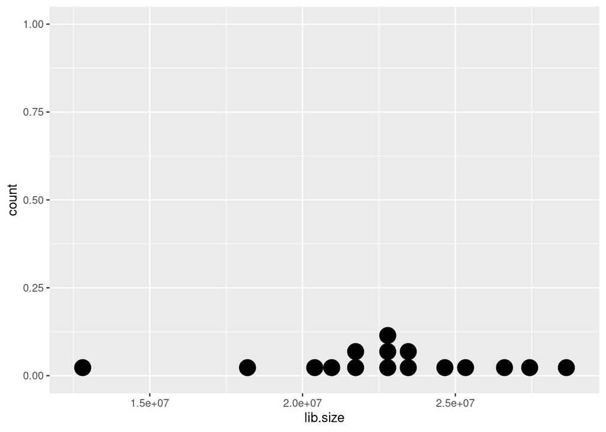

```r
ggplot(Ldge$samples, aes(x = lib.size)) + geom_dotplot()
```

#### Eliminación de filas con conteos bajos

```r
keep = rowSums(cpm(Ldge)>1) >= 2
Ldge = Ldge[keep, keep.lib.sizes = FALSE]
PRJNA548871_keep = PRJNA548871[keep,]
```

### Realizamos el análisis de expresión diferencial

Una vez eliminado los genes con conteos bajos realizamos el análisis de expresión diferencial. Lo estimaremos por dispersión común y por gen.

```r
## Estimación dispersión común
Ldge.c = estimateCommonDisp(Ldge)
## Estimación dispersión por gen
Ldge.t =  estimateTagwiseDisp(Ldge.c)
## Aplicamos exactTest
et.c = exactTest(Ldge.c)
et.t = exactTest(Ldge.t)
```

Mostramos los resultados con topTags.

```r
topTags(et.c)
```

```
## Comparison of groups:  OIR-nonOIR
##                       logFC    logCPM        PValue          FDR
## ENSMUSG00000069919 9.442920 6.1422756 4.407037e-102 5.819052e-98
## ENSMUSG00000069917 8.842066 6.0756392  1.142444e-95 7.542417e-92
## ENSMUSG00000073940 5.499966 5.5259403  6.754187e-54 2.972743e-50
## ENSMUSG00000052305 5.371840 6.3459806  1.287555e-52 4.250221e-49
## ENSMUSG00000049723 5.360264 4.7687144  8.750590e-51 2.310856e-47
## ENSMUSG00000025270 9.501283 1.0705485  3.163205e-50 6.961160e-47
## ENSMUSG00000009185 9.326834 0.8954363  6.759800e-48 1.275091e-44
## ENSMUSG00000022126 5.844098 1.5280020  8.148525e-43 1.344914e-39
## ENSMUSG00000050335 4.447117 6.1417079  4.248511e-40 6.233038e-37
## ENSMUSG00000034311 5.356907 1.1023280  2.385558e-37 3.149890e-34
```

```r
topTags(et.t)
```

```
## Comparison of groups:  OIR-nonOIR
##                       logFC   logCPM       PValue          FDR
## ENSMUSG00000069919 9.427981 6.142276 3.054286e-33 4.032880e-29
## ENSMUSG00000069917 8.828511 6.075639 8.144547e-27 5.377030e-23
## ENSMUSG00000005413 4.144086 8.938815 1.076183e-25 4.736639e-22
## ENSMUSG00000020649 3.004403 4.596451 8.046299e-24 2.656083e-20
## ENSMUSG00000040564 1.820707 4.580612 2.017812e-23 5.328637e-20
## ENSMUSG00000068129 1.405330 5.841902 1.287750e-22 2.833908e-19
## ENSMUSG00000036067 1.508714 6.189062 1.565761e-21 2.953473e-18
## ENSMUSG00000050335 4.446524 6.141708 5.069549e-21 8.367290e-18
## ENSMUSG00000079017 2.564282 6.515104 6.120699e-20 8.979745e-17
## ENSMUSG00000062593 3.304972 5.673810 2.199449e-19 2.904152e-16
```

A continuación obtendremos los p-valores ajustados por los métodos de Benjamini-Hochberg y de Bonferroni.

```r
pvalues_c = et.c$table$PValue
pvalues_t =et.t$table$PValue
pBH_c = p.adjust(pvalues_c, method = "BH")
pBH_t = p.adjust(pvalues_t, method = "BH")
pBonferroni_c = p.adjust(pvalues_c, method = "bonferroni")
pBonferroni_t = p.adjust(pvalues_t, method = "bonferroni")
```

Fijamos una tasa de error alpha = 0.05. Y veremos aquellos genes con un p-valor y p-valor ajustado menores a nuestra tasa de especificada, es decir que sean significativos. Utilizaremos los p-valores obtenidos con la dispersión por gen.

```r
length(pvalues_t)
```

```
## [1] 13204
```

```r
alpha = 0.05
significativos_p_t = which(pvalues_t < alpha)
length(significativos_p_t)
```

```
## [1] 3349
```

```r
significativos_BH_t = which(pBH_t < alpha)
length(significativos_BH_t)
```

```
## [1] 1787
```

```r
significativos_Bonferroni_t =  which(pBonferroni_t < alpha)
length(significativos_Bonferroni_t)
```

```
## [1] 376
```

Si nos fijamos en los resultados de 13204 genes que tenemos una vez descartado aquellos con pocos conteos, nos dan 3349 con un p-valor menor a 0,05 (significativos), y ajustando los p-valores con Benjamini-Hochberg y Bonferroni nos dan 1787 y 376 genes significativos, respectivamente. Como es de esperar el método de Bonferroni es más conservador obteniendo un menor número de genes significativos.

### Generar el data.frame con los p-valores y p-valores ajustados

Primero guardaremos en un vector el nombre de las cabeceras para luego implementarlas y generamos el data.frame. Generaremos el data.frame con los sin los hipervínculos correspondientes al identificador, y después con ellos.

Primero generaremos el data.frame de con los p-valores obtenidos con la estimación de dispersión común (estimateCommonDisp).

```r
cabeceras_c = c(colnames(rowData(PRJNA548871_keep)), "p.value_CommonDisp", "p.adjust_BH", "p.adjust_Bonferroni")
ensembl_url = asierortega::ensembl2url(rowData(PRJNA548871_keep)[, "ENSEMBL"])
entrzid_url = asierortega::entrezid2url(rowData(PRJNA548871_keep)[, "ENTREZID"])
## Construimos dataframe
df51_c = data.frame(rowData(PRJNA548871_keep)[, "ENSEMBL"], rowData(PRJNA548871_keep)[, "GENENAME"], rowData(PRJNA548871_keep)[, "ENTREZID"], rowData(PRJNA548871_keep)[, "SYMBOL"], pvalues_c, pBH_c, pBonferroni_c)
df51_c_hip = data.frame(ensembl_url, rowData(PRJNA548871_keep)[, "GENENAME"], entrzid_url, rowData(PRJNA548871_keep)[, "SYMBOL"], pvalues_c, pBH_c, pBonferroni_c)

colnames(df51_c) = cabeceras_c
colnames(df51_c_hip) = cabeceras_c
head(df51_c)
```

|  | ENSEMBL | GENENAME | ENTREZID | SYMBOL | p.value_CommonDisp | p.adjust_BH | p.adjust_Bonferroni |
| --- | --- | --- | --- | --- | --- | --- | --- |
| 1 | ENSMUSG00000000001 | guanine nucleotide binding protein (G protein), alpha inhibiting 3 | 14679 | Gnai3 | 8.840804e-01 | 9.793941e-01 | 1.000000e+00 |
| 2 | ENSMUSG00000000028 | cell division cycle 45 | 12544 | Cdc45 | 1.133555e-09 | 4.240075e-08 | 1.496747e-05 |
| 3 | ENSMUSG00000000056 | nuclear prelamin A recognition factor | 67608 | Narf | 5.851944e-02 | 3.050496e-01 | 1.000000e+00 |
| 4 | ENSMUSG00000000058 | caveolin 2 | 12390 | Cav2 | 5.914211e-01 | 8.990321e-01 | 1.000000e+00 |
| 5 | ENSMUSG00000000078 | Kruppel-like factor 6 | 23849 | Klf6 | 6.055691e-01 | 9.042942e-01 | 1.000000e+00 |
| 6 | ENSMUSG00000000085 | sex comb on midleg homolog 1 | 29871 | Scmh1 | 8.810952e-01 | 9.785825e-01 | 1.000000e+00 |

A continuación generaremos el data.frame de con los p-valores obtenidos con la estimación de dispersión por gen (estimateTagwiseDisp).

```r
## Sin hipervinculo
cabeceras_t = c(colnames(rowData(PRJNA548871_keep)), "p.value_TagwiseDisp", "p.adjust_BH", "p.adjust_Bonferroni")
ensembl_url = asierortega::ensembl2url(rowData(PRJNA548871_keep)[, "ENSEMBL"])
entrzid_url = asierortega::entrezid2url(rowData(PRJNA548871_keep)[, "ENTREZID"])
## Construimos data.frame
df51_t = data.frame(rowData(PRJNA548871_keep)[, "ENSEMBL"], rowData(PRJNA548871_keep)[, "GENENAME"], rowData(PRJNA548871_keep)[, "ENTREZID"], rowData(PRJNA548871_keep)[, "SYMBOL"], pvalues_t, pBH_t, pBonferroni_t)
df51_t_hip = data.frame(ensembl_url, rowData(PRJNA548871_keep)[, "GENENAME"], entrzid_url, rowData(PRJNA548871_keep)[, "SYMBOL"], pvalues_t, pBH_t, pBonferroni_t)

colnames(df51_t) = cabeceras_t
colnames(df51_t_hip) = cabeceras_t
head(df51_t)
```

|  | ENSEMBL | GENENAME | ENTREZID | SYMBOL | p.value_TagwiseDisp | p.adjust_BH | p.adjust_Bonferroni |
| --- | --- | --- | --- | --- | --- | --- | --- |
| 1 | ENSMUSG00000000001 | guanine nucleotide binding protein (G protein), alpha inhibiting 3 | 14679 | Gnai3 | 7.451405e-01 | 0.8951719393 | 1.0000000 |
| 2 | ENSMUSG00000000028 | cell division cycle 45 | 12544 | Cdc45 | 1.158053e-04 | 0.0022856409 | 1.0000000 |
| 3 | ENSMUSG00000000056 | nuclear prelamin A recognition factor | 67608 | Narf | 1.330757e-05 | 0.0003878878 | 0.1757132 |
| 4 | ENSMUSG00000000058 | caveolin 2 | 12390 | Cav2 | 4.159099e-01 | 0.6852128572 | 1.0000000 |
| 5 | ENSMUSG00000000078 | Kruppel-like factor 6 | 23849 | Klf6 | 1.877048e-01 | 0.4430558955 | 1.0000000 |
| 6 | ENSMUSG00000000085 | sex comb on midleg homolog 1 | 29871 | Scmh1 | 8.096860e-01 | 0.9223076660 | 1.0000000 |

Ordenaremos el data.frame generado de manera ascendente para así poder ver los primero los genes que presentan mayor expresión diferencial en el análisis.

```r
df51_c_sorted = df51_c[order(df51_c$p.value_CommonDisp, decreasing = FALSE),]
df51_t_sorted = df51_t[order(df51_t$p.value_TagwiseDisp, decreasing = FALSE),]

head(df51_c_sorted)
```

|  | ENSEMBL | GENENAME | ENTREZID | SYMBOL | p.value_CommonDisp | p.adjust_BH | p.adjust_Bonferroni |
| --- | --- | --- | --- | --- | --- | --- | --- |
| 11129 | ENSMUSG00000069919 | hemoglobin alpha, adult chain 1 | 15122 | Hba-a1 | 4.407037e-102 | 5.819052e-98 | 5.819052e-98 |
| 11128 | ENSMUSG00000069917 | hemoglobin alpha, adult chain 2 | 110257 | Hba-a2 | 1.142444e-95 | 7.542417e-92 | 1.508483e-91 |
| 11428 | ENSMUSG00000073940 | hemoglobin, beta adult t chain | 101488143 | Hbb-bt | 6.754187e-54 | 2.972743e-50 | 8.918228e-50 |
| 9708 | ENSMUSG00000052305 | hemoglobin, beta adult major chain | 15129 | Hbb-b1 | 1.287555e-52 | 4.250221e-49 | 1.700088e-48 |
| 9439 | ENSMUSG00000049723 | matrix metallopeptidase 12 | 17381 | Mmp12 | 8.750590e-51 | 2.310856e-47 | 1.155428e-46 |
| 3493 | ENSMUSG00000025270 | aminolevulinic acid synthase 2, erythroid | 11656 | Alas2 | 3.163205e-50 | 6.961160e-47 | 4.176696e-46 |

```r
head(df51_t_sorted)
```

|  | ENSEMBL | GENENAME | ENTREZID | SYMBOL | p.value_TagwiseDisp | p.adjust_BH | p.adjust_Bonferroni |
| --- | --- | --- | --- | --- | --- | --- | --- |
| 11129 | ENSMUSG00000069919 | hemoglobin alpha, adult chain 1 | 15122 | Hba-a1 | 3.054286e-33 | 4.032880e-29 | 4.032880e-29 |
| 11128 | ENSMUSG00000069917 | hemoglobin alpha, adult chain 2 | 110257 | Hba-a2 | 8.144547e-27 | 5.377030e-23 | 1.075406e-22 |
| 608 | ENSMUSG00000005413 | heme oxygenase 1 | 15368 | Hmox1 | 1.076183e-25 | 4.736639e-22 | 1.420992e-21 |
| 1870 | ENSMUSG00000020649 | ribonucleotide reductase M2 | 20135 | Rrm2 | 8.046299e-24 | 2.656083e-20 | 1.062433e-19 |
| 8184 | ENSMUSG00000040564 | apolipoprotein C-I | 11812 | Apoc1 | 2.017812e-23 | 5.328637e-20 | 2.664318e-19 |
| 11003 | ENSMUSG00000068129 | cystatin F (leukocystatin) | 13011 | Cst7 | 1.287750e-22 | 2.833908e-19 | 1.700345e-18 |

### Función sumex2df

He realiado una función llamada **sumex2df** el cual con debemos introducir como argumento el summarize experiment, el nombre de la columna donde se encuentran la información de las muestras con tratamiento y control (“treatment” por defecto), el método que utilizaremos “c” para aplicar la estimación de dispersión común y “t” para estimación dispersión por gen. Además debemos decirle si queremos incluir los hipervínculos o no en los identificadores (ENSEMBL y ENTREZID).

```r
df51_c_funcion = sumex2df(PRJNA548871_keep, columnName = "treatment", method = "c", hiperlink = FALSE)
df51_t_funcion = sumex2df(PRJNA548871_keep, columnName = "treatment", method = "t", hiperlink = FALSE)
df51_c_hip_funcion = sumex2df(PRJNA548871_keep, columnName = "treatment", method = "c", hiperlink = TRUE)
df51_t_hip_funcion = sumex2df(PRJNA548871_keep, columnName = "treatment", method = "c", hiperlink = TRUE)
```

### Informe

A continnuación generaremos los dos informes con los data.frames con los hipervínculos que hemos creado anteriormente. Para ello utilizaremos el paquete Reporting Tools.

```r
nombre_c = "Informe_ED_CommonDisp_PRJNA548871"
nombre_t = "Informe_ED_TagwiseDisp_PRJNA548871"


report_c = HTMLReport(shortName = nombre_c, title = nombre_c, reportDirectory = "../docs/articles")
report_t = HTMLReport(shortName = nombre_t, title = nombre_t, reportDirectory = "../docs/articles")

publish(df51_c_hip, report_c)
publish(df51_t_hip, report_t)

finish(report_c)
```

```
## [1] "../docs/articles/Informe_ED_CommonDisp_PRJNA548871.html"
```

```r
finish(report_t)
```

```
## [1] "../docs/articles/Informe_ED_TagwiseDisp_PRJNA548871.html"
```

También he creado una función que dado el dataframe, el nombre del informe y la ruta genera el informe HTML (por defecto en el directorio actual). Se llama “makeReport”.

```r
makeReport(df51_c_funcion, name = "Reportdeprueba", path = "../docs/articles")
```

```
## [1] "../docs/articles/Reportdeprueba.html"
```

### Conclusiones del estudio

Los datos con los que hemos trabajado corresponden al siguiente [articulo](https://onlinelibrary.wiley.com/doi/full/10.1002/glia.23810). En dicho artículo se menciona que el análisis de expresión diferencial se ha realizado con el método DESeq2, lo que las conclusiones las realizaremos en la viñeta “tarea42” que es donde aplicamos este análisis.

### Normalización de RNA-seq (opcional)

En principio no debemos normalizar los datos de RNA-seq pero en caso de necesitarlo en un futúro, a continuación se muestra la normalización utilizando el método TMM.

Utilizaremos la función calcNormFactors el cual calcula los factores de escala para convertir los tamaños del librería sin procesar en tamaños efectivos, aquí aplicamos el método TMM. Una vez hecho esto podemos ver como los factores normalizados cambian.

Realizamos la estimación de la función de densidad de los conteos para las distintas muestras con los conteos originales y una vez aplicados la normalización TMM.

```r
data(PRJNA548871, package = "asierortega")
PRJNA548871 = PRJNA548871[which(apply(rowData(PRJNA548871),1,function(y) sum(is.na(y))!=3)),]

counts0 = assay(PRJNA548871)
counts0 = data.frame(counts0)
df0 = reshape2::melt(counts0)
```

```r
ini_fdens = ggplot(df0, aes(x=value, colour = variable)) + stat_ecdf()
ini_fdist = ggplot(df0, aes(x = value,colour = variable))+geom_density()

## Normalizamos con el metodo TMM
Ldge_norm = calcNormFactors(Ldge, method = "TMM")
Ldeg_norm = estimateCommonDisp(Ldge_norm)

counts1 = Ldeg_norm$pseudo.counts
counts1 = data.frame(counts1)
df0 = reshape2::melt(counts1)
pos_fdens = ggplot(df0, aes(x = value,colour = variable)) + stat_ecdf()
pos_fdist = ggplot(df0, aes(x = value,colour = variable)) + geom_density()
```

```r
summary(Ldge$samples[,"norm.factors"])
```

```
##    Min. 1st Qu.  Median    Mean 3rd Qu.    Max.
##       1       1       1       1       1       1
```

```r
summary(Ldge_norm$samples[,"norm.factors"])
```

```
##    Min. 1st Qu.  Median    Mean 3rd Qu.    Max.
##  0.9265  0.9690  0.9895  1.0010  1.0196  1.0937
```

Mostramos las gráficas generadas.

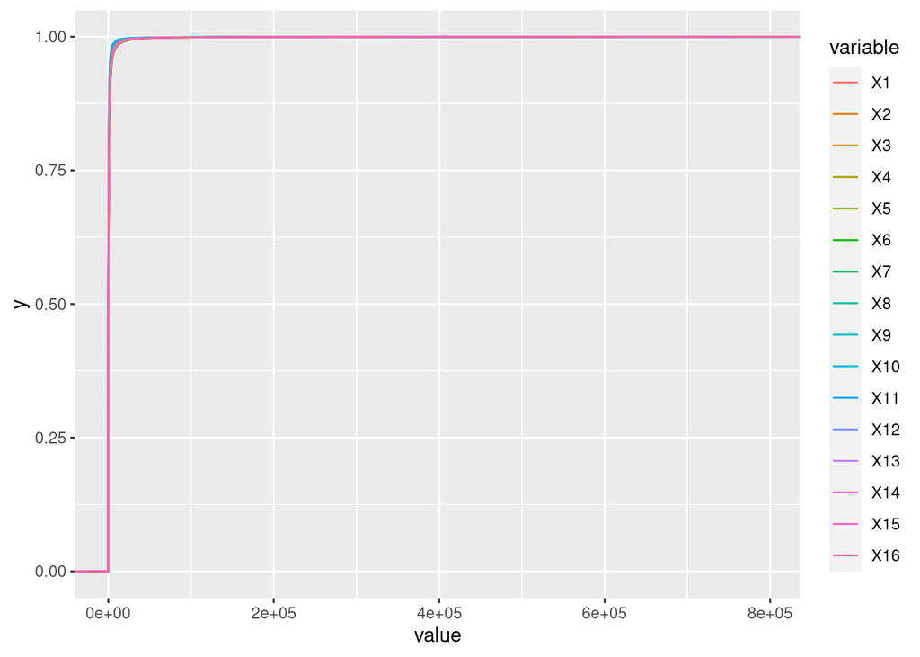

```r
## funcion de densidad de los conteos inicial
ini_fdens
```

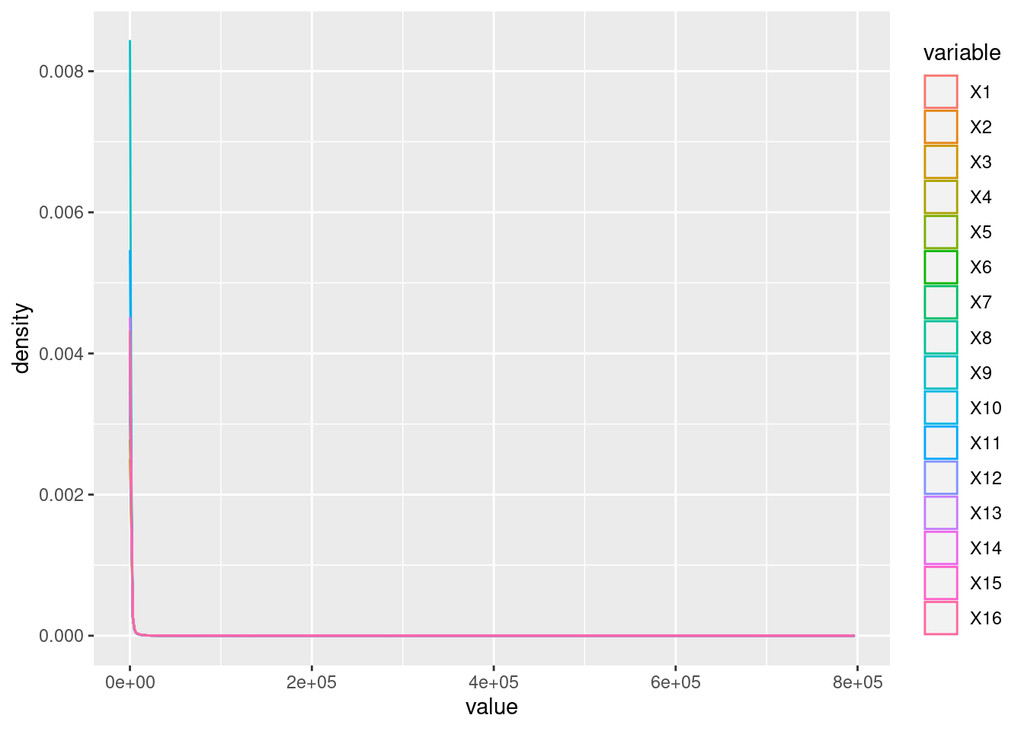

```r
## funcion de distribucion de los conteos inicial
ini_fdist
```

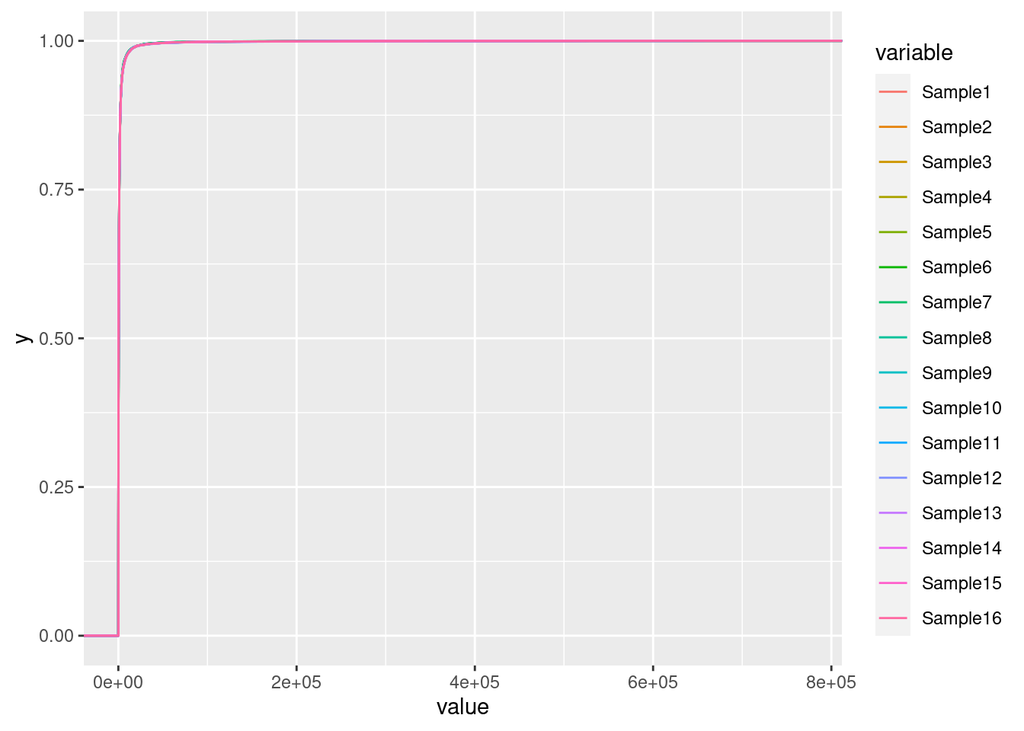

```r
## funcion de densidad de los conteos nromalizado con TMM
pos_fdens
```

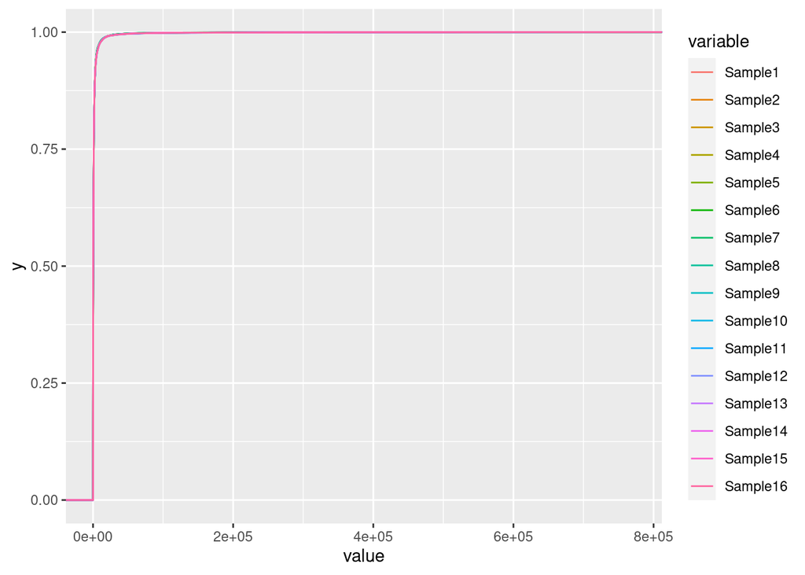

```r
## funcion de distribucion de los conteos normalizado con TMM
pos_fdens
```